# Palmer Archipelago penguins

39123456

## Background

The study looked at the characteristics of three species of penguin living on the Palmer Archipelago: the Adelie penguin (Pygoscelis adeliae), the Chinstrap penguin’s (Pygoscelis antarcticus) and the Gentoo penguin (Pygoscelis papua).

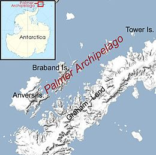

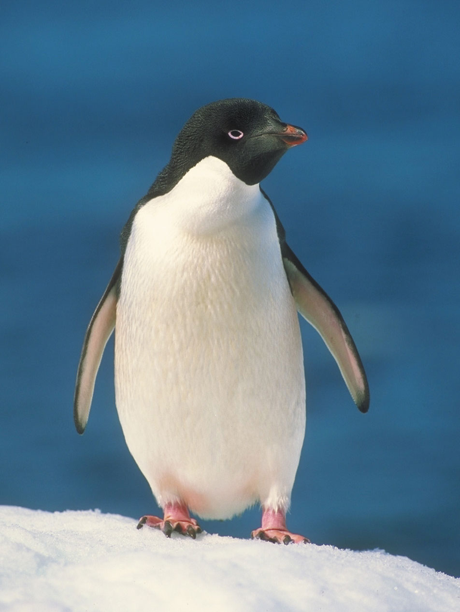

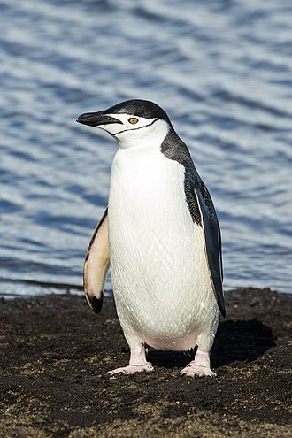

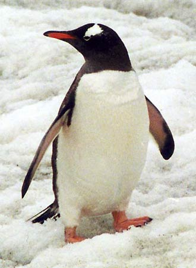

Figure 1. Palmer penguins

```r
glimpse(penguins)
```

[output not shown]

```r
old_names = colnames(penguins_raw)
penguins = penguins_raw %>%
    janitor::clean_names()
```

## Flipper length

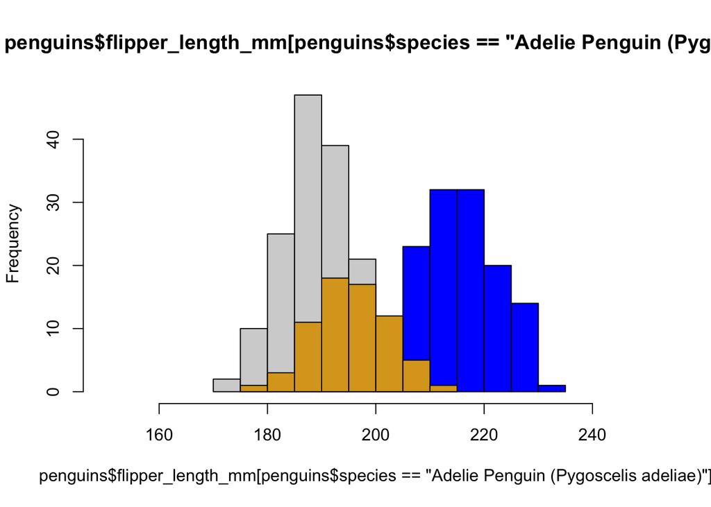

```r
hist(penguins$flipper_length_mm[penguins$species == "Adelie Penguin (Pygoscelis adeliae)"], xlim = range(150,250))
hist(penguins$flipper_length_mm[penguins$species == "Gentoo penguin (Pygoscelis papua)"], add = TRUE, col = "blue")
hist(penguins$flipper_length_mm[penguins$species == "Chinstrap penguin (Pygoscelis antarctica)"], add = TRUE, col = "goldenrod")
```

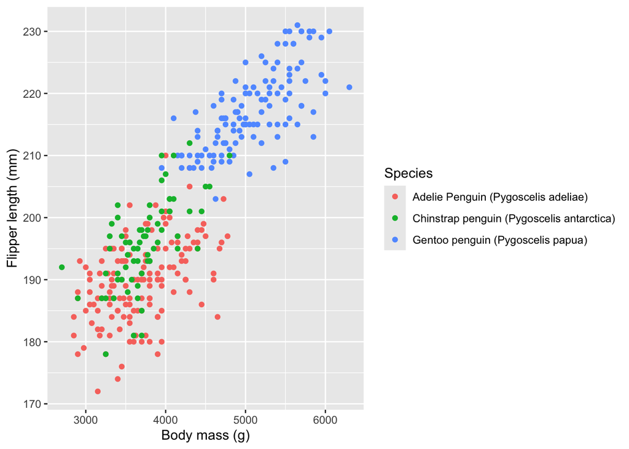

Figure 2

```r
penguins %>%
  ggplot() +
  # add the aesthetics
  aes(x = body_mass_g,
      y = flipper_length_mm,
      colour = species) +
  # add a geometry
  geom_point() +
  # tidy up the labels
  labs(x = "Body mass (g)",
       y = "Flipper length (mm)",
       colour = "Species")
```

We test if mean flipper lengths are the same in Adelie and Chinstrap penguins.

```r
penguins %>% group_by(species)  %>%
  select(c(species, flipper_length_mm)) %>% drop_na() %>%
  summarise(
    n = n(),
    mean = mean(flipper_length_mm),
    sd = sd(flipper_length_mm)
  ) -> flippers
```

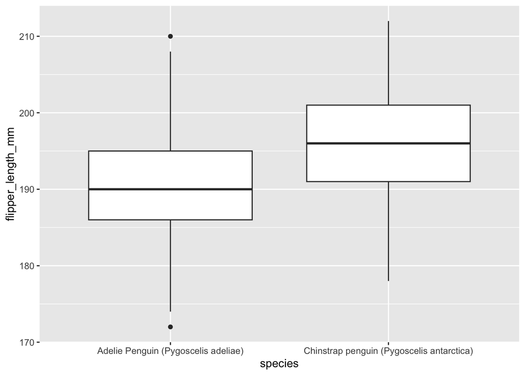

```r
penguins %>% filter(species != "Gentoo penguin (Pygoscelis papua)") %>%
  group_by(species)  %>%
  select(c(species, flipper_length_mm)) %>%
  drop_na() -> mydata
  ggplot(mydata,aes(x = species, y = flipper_length_mm)) + geom_boxplot()
```

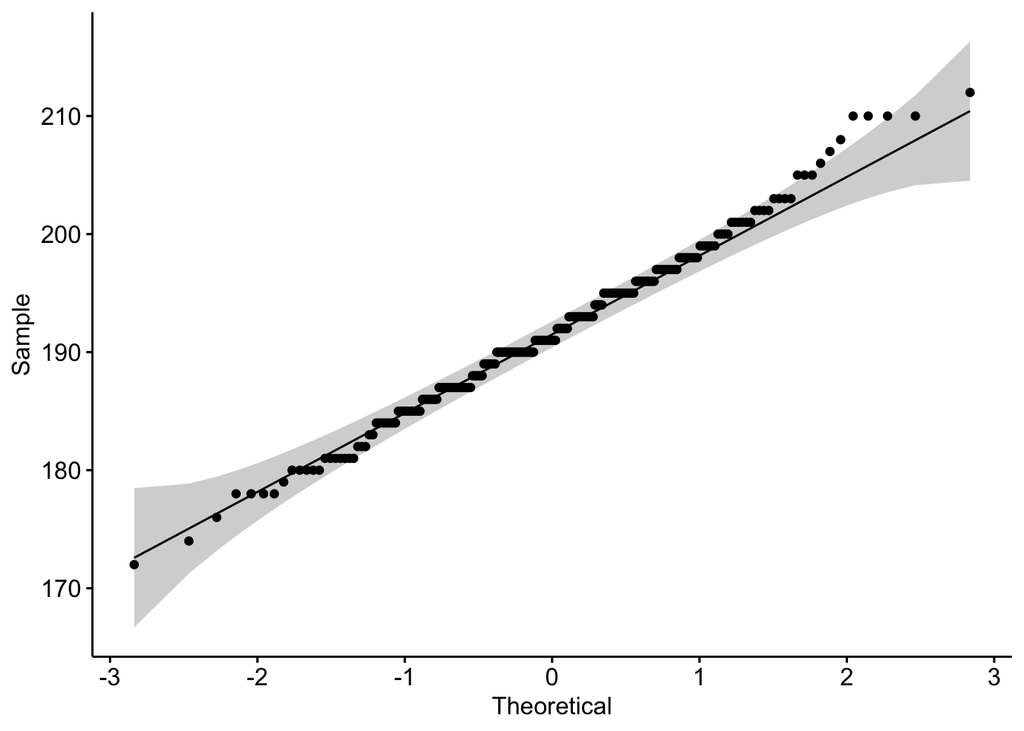

```r
library(ggpubr)
ggqqplot(mydata, x = "flipper_length_mm")
```

Variances look about equal. The data looks to be approximately normally distributed.

```r
idxA <- mydata$species %in% "Adelie Penguin (Pygoscelis adeliae)"
idxC <- mydata$species %in% "Chinstrap penguin (Pygoscelis antarctica)"
t.test(mydata$flipper_length_mm[idxA],mydata$flipper_length_mm[idxC],var.equal = TRUE)
```

[output not shown]

## Culman length

Figure 3 shows that the culmen is roughly proportional to body mass for Adelie and Gentoo penguins. Chinstrap penguins tend to have longer beaks. We use a t-test to determine if the culmen lengths are approximately the same for Chinstrap and Gentoo penguins.

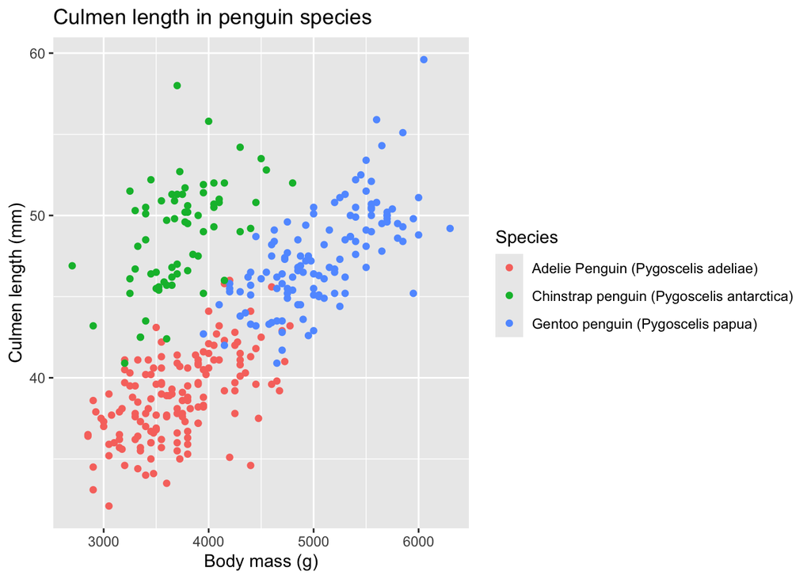

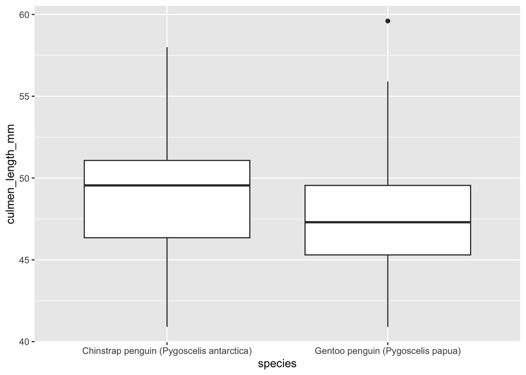

```r
penguins %>% filter(species != "Adelie Penguin (Pygoscelis adeliae)") %>%
  group_by(species)  %>%
  select(c(species, culmen_length_mm)) %>%
  drop_na() -> mydata
  ggplot(mydata,aes(x = species, y = culmen_length_mm)) + geom_boxplot()
```

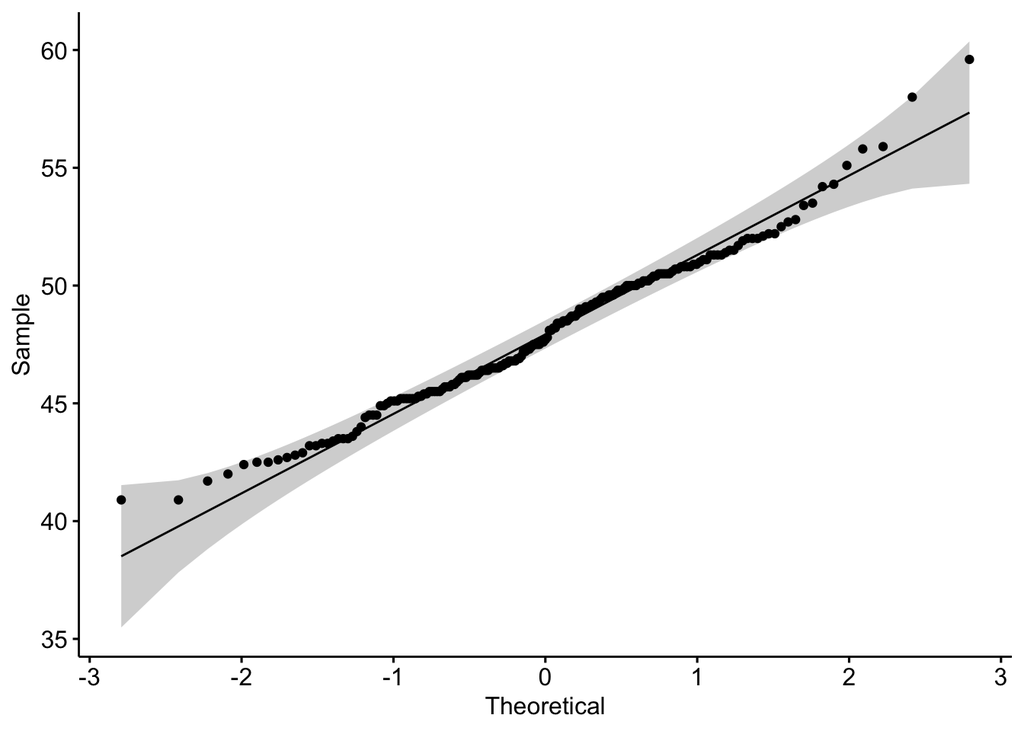

```r
library(ggpubr)
ggqqplot(mydata, x = "culmen_length_mm")
```

The variances are approximately equal. The data is approximately normal.

```r
idxC <- mydata$species %in% "Chinstrap penguin (Pygoscelis antarctica)"
idxG <- mydata$species %in% "Gentoo penguin (Pygoscelis papua)"
t.test(mydata$culmen_length_mm[idxC],mydata$culmen_length_mm[idxG],var.equal = TRUE)
```

```
##
##  Two Sample t-test
##
## data:  mydata$culmen_length_mm[idxC] and mydata$culmen_length_mm[idxG]
## t = 2.7694, df = 189, p-value = 0.006176
## alternative hypothesis: true difference in means is not equal to 0
## 95 percent confidence interval:
##  0.3823625 2.2755285
## sample estimates:
## mean of x mean of y
##  48.83382  47.50488
```

## Sex

We check the ratio of gender in the colonies of each species.

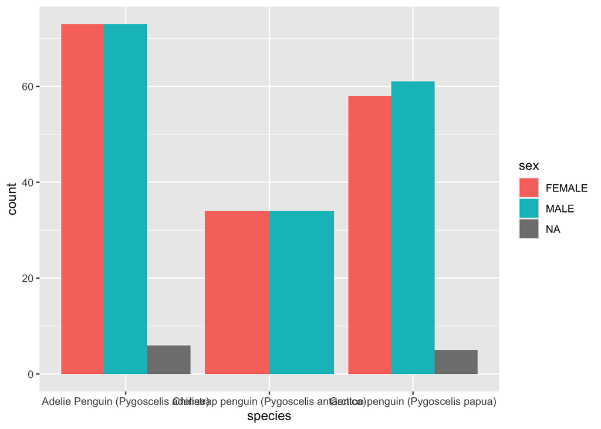

```r
penguins %>% select(species, sex) %>%
  ggplot(aes(species, ..count..))  + geom_bar(aes(fill = sex), position = "dodge")
```

Test whether same number of males and females in each species using a chi-squared test.

```r
penguins %>% select(species, sex) %>% drop_na() %>% group_by(sex) -> mydata
chitest <- chisq.test(table(mydata$species,mydata$sex))
any(chitest$expectated < 5)
```

```
## [1] FALSE
```

```r
chitest
```

```
##
##  Pearson's Chi-squared test
##
## data:  table(mydata$species, mydata$sex)
## X-squared = 0.048607, df = 2, p-value = 0.976
```

All the expectation values are > 5. To within the error of the experiment, the sex.ratio is 1.0 for all three species.

## Conclusion

Penguins are great.